# Chapter 3 Data Pre-processing Exercises

Author: Rick Dean

Article date: 2021-02-01

Abstract

The following notes/scripts/plots are inspired by Chapter 3 Data Pre-processing Exercises 3-2 of [Applied Predictive Modeling](http://appliedpredictivemodeling.com/) by Max Kuhn and Kjell Johnson.

```r
library(knitr)
library(data.table)
library(ggplot2)
library(mlbench)
library(grid)
library(gtable)
library(RregressPkg)
library(RplotterPkg)
```

## The Soybean Dataset

### (a) Investigate the frequency disributions

Task: Set up the data set.

```r
data(Soybean, package = "mlbench")
soybean_dt <- as.data.table(Soybean)
str(soybean_dt)
```

```
## Classes 'data.table' and 'data.frame':   683 obs. of  36 variables:
##  $ Class          : Factor w/ 19 levels "2-4-d-injury",..: 11 11 11 11 11 11 11 11 11 11 ...
##  $ date           : Factor w/ 7 levels "0","1","2","3",..: 7 5 4 4 7 6 6 5 7 5 ...
##  $ plant.stand    : Ord.factor w/ 2 levels "0"<"1": 1 1 1 1 1 1 1 1 1 1 ...
##  $ precip         : Ord.factor w/ 3 levels "0"<"1"<"2": 3 3 3 3 3 3 3 3 3 3 ...
##  $ temp           : Ord.factor w/ 3 levels "0"<"1"<"2": 2 2 2 2 2 2 2 2 2 2 ...
##  $ hail           : Factor w/ 2 levels "0","1": 1 1 1 1 1 1 1 2 1 1 ...
##  $ crop.hist      : Factor w/ 4 levels "0","1","2","3": 2 3 2 2 3 4 3 2 4 3 ...
##  $ area.dam       : Factor w/ 4 levels "0","1","2","3": 2 1 1 1 1 1 1 1 1 1 ...
##  $ sever          : Factor w/ 3 levels "0","1","2": 2 3 3 3 2 2 2 2 2 3 ...
##  $ seed.tmt       : Factor w/ 3 levels "0","1","2": 1 2 2 1 1 1 2 1 2 1 ...
##  $ germ           : Ord.factor w/ 3 levels "0"<"1"<"2": 1 2 3 2 3 2 1 3 2 3 ...
##  $ plant.growth   : Factor w/ 2 levels "0","1": 2 2 2 2 2 2 2 2 2 2 ...
##  $ leaves         : Factor w/ 2 levels "0","1": 2 2 2 2 2 2 2 2 2 2 ...
##  $ leaf.halo      : Factor w/ 3 levels "0","1","2": 1 1 1 1 1 1 1 1 1 1 ...
```

[output cut: 23 more lines]

The response variable *Class* is a nominal variable with 19 class types. The remaining 35 predictor variables have categorical values encoded numerically, with the first value encoded as “0”, the second as “1”, and so forth.

1. Separate out non-predictor variables *Class*, *date*:

```r
class_dt <- soybean_dt[, .(Class)]
date_dt <- soybean_dt[, .(date)]
soybean_dt <- soybean_dt[, !c("Class", "date")]
```

2. Are there any NA values? If so remove observations with NA values:

```r
(any_na <- base::anyNA(soybean_dt))
```

```
## [1] TRUE
```

```r
dt <- na.omit(soybean_dt)
```

3. Plot frequency distributions:

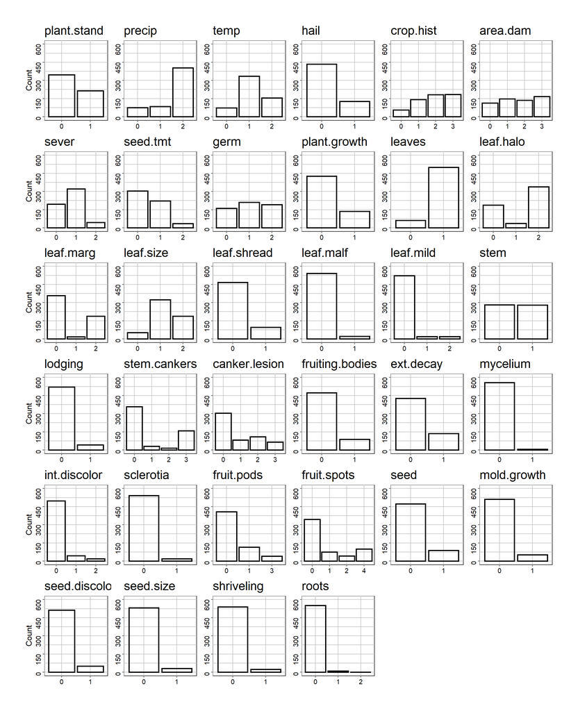

```r
RplotterPkg::multi_bar_plot(
  df = dt,
  variables = colnames(dt),
  columns = 6,
  col_width = 2.0,
  row_height = 2.5,
  y_limits = c(0,600),
  y_major_breaks = seq(0, 600, 150)
)
```

Most of the predictors are skewed toward the “0” level. A few like *precip* and *leaves* are skewed to the upper levels.

### (b) Missing values

Are there particular predictors that are more likely to be missing? Is the pattern of missing data related to the classes?

Task: Apply RregressPkg::plot_replace_missing() to plot the frequency of NAs’ among predictor variables.

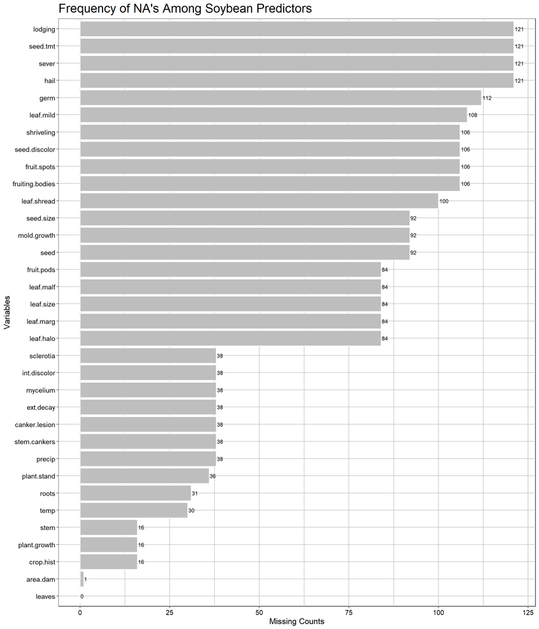

```r
plot_1 <- RregressPkg::plot_replace_missing(
  df = soybean_dt,
  variables = colnames(soybean_dt),
  title = "Frequency of NA's Among Soybean Predictors",
  bar_size = 0.6,
  bar_color = "white",
  bar_labels = TRUE,
  bar_label_size = 3,
  do_coord_flip = TRUE,
  order_bars = "asc"
)
plot_1$missing_plot
```

It appears that there are subgroups of predictors with equal or near equal numbers of missing values.

Task: Plot the frequency of NAs’ across the values of the *Class*.

1. Column bind *soybean_dt* and *class_dt*

```r
soybean_class_dt <- cbind(soybean_dt, class_dt)
```

2. In *soybean_class_dt* add a variable *na_count* that has the number of NAs’ for each observation:

```r
na_count_vt <- apply(soybean_dt, 1, function(x) sum(is.na(x)))
soybean_class_dt[, na_count := na_count_vt]
```

```r
class_na_count_dt <- soybean_class_dt[, lapply(.SD, function(x){sum(is.na(x))}), by = Class]
class_na_count_long_dt <- data.table::melt(
  class_na_count_dt, id.vars = "Class",
  measure.vars = colnames(soybean_dt),
  variable.name = "Predictor",
  value.name = "NA_Count")
```

3. Plot the predictors bar chart for each *Class*:

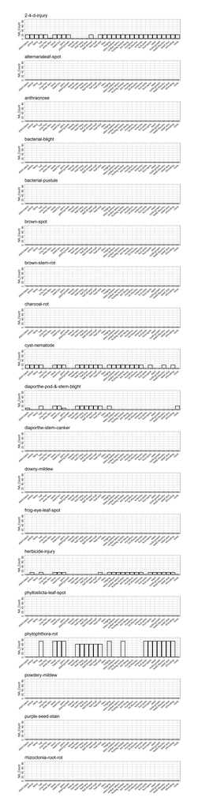

```r
RplotterPkg::multi_bar_plot(
  df = class_na_count_long_dt,
  factor_var = "Class",
  factor_x = "Predictor",
  aes_y = "NA_Count",
  columns = 1,
  col_width = 10,
  row_height = 2.5,
  rot_x_tic_angle = 40,
  y_limits = c(0,80),
  y_major_breaks = seq(0,80,20)
)
```

Five of the nineteen classes have some level of NA counts. It appears that the *phytophthora-rot* class tops the list with many NA’s associated with it. The classes *2-4-d-injury* and *cyst-nematode* have some observations that have NA’s across nearly all the predictors.